# Codebook for combined

## fBodyGyro-std()-X

| Feature | Result |
| --- | --- |
| Variable type | numeric |
| Number of missing obs. | 0 (0 %) |
| Number of unique values | 10297 |
| Median | -0.91 |
| 1st and 3rd quartiles | -0.99; -0.52 |
| Min. and max. | -1; 1 |

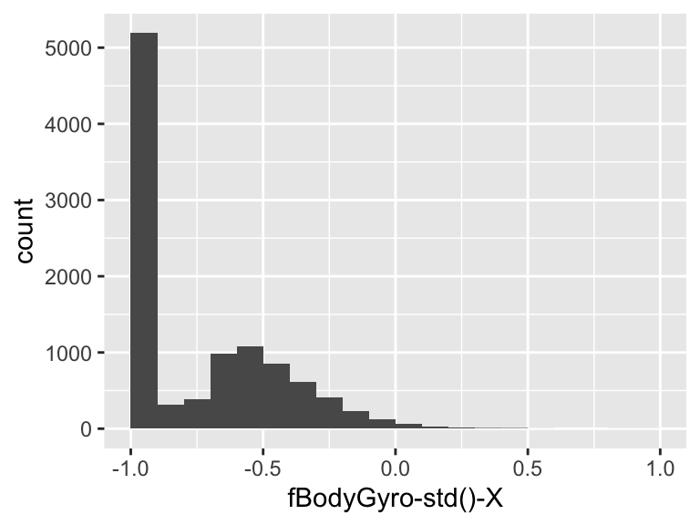

## fBodyGyro-std()-Y

| Feature | Result |
| --- | --- |
| Variable type | numeric |
| Number of missing obs. | 0 (0 %) |
| Number of unique values | 10293 |
| Median | -0.91 |
| 1st and 3rd quartiles | -0.98; -0.44 |
| Min. and max. | -1; 1 |

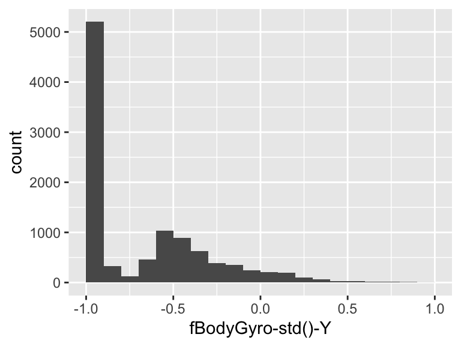

## fBodyGyro-std()-Z

| Feature | Result |
| --- | --- |
| Variable type | numeric |
| Number of missing obs. | 0 (0 %) |
| Number of unique values | 10295 |
| Median | -0.89 |
| 1st and 3rd quartiles | -0.99; -0.42 |
| Min. and max. | -1; 1 |

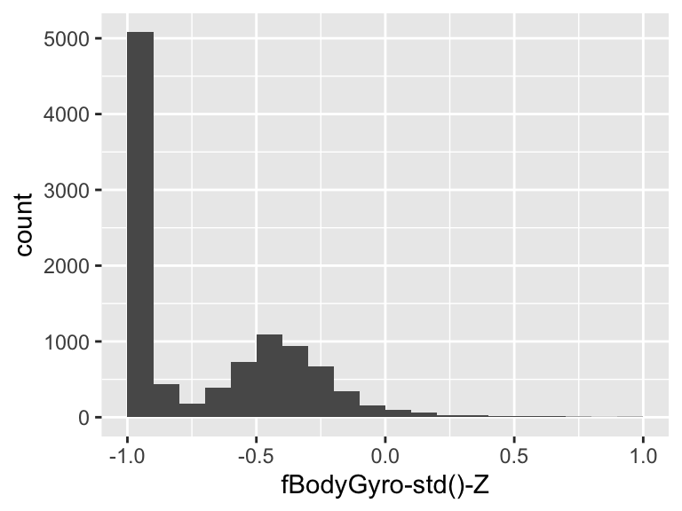

## fBodyGyro-meanFreq()-X

| Feature | Result |
| --- | --- |
| Variable type | numeric |
| Number of missing obs. | 0 (0 %) |
| Number of unique values | 10298 |
| Median | -0.1 |
| 1st and 3rd quartiles | -0.27; 0.07 |
| Min. and max. | -1; 1 |

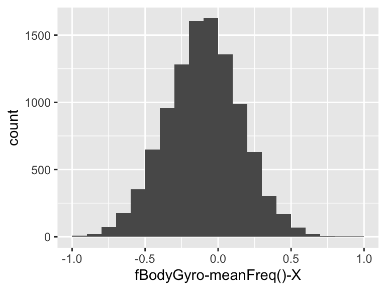

## fBodyGyro-meanFreq()-Y

| Feature | Result |
| --- | --- |
| Variable type | numeric |
| Number of missing obs. | 0 (0 %) |
| Number of unique values | 10299 |
| Median | -0.17 |
| 1st and 3rd quartiles | -0.36; 0.01 |
| Min. and max. | -1; 1 |

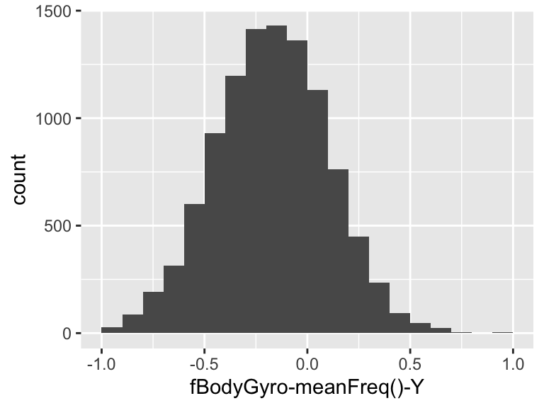

## fBodyGyro-meanFreq()-Z

| Feature | Result |
| --- | --- |
| Variable type | numeric |
| Number of missing obs. | 0 (0 %) |
| Number of unique values | 10299 |
| Median | -0.05 |
| 1st and 3rd quartiles | -0.23; 0.12 |
| Min. and max. | -1; 1 |

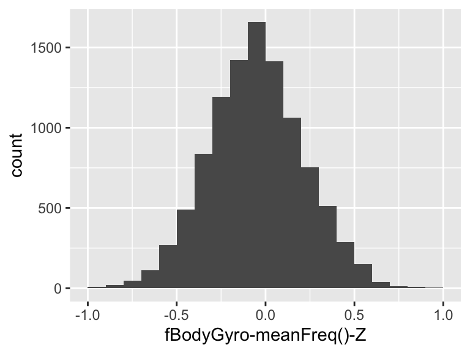

## fBodyAccMag-mean()

| Feature | Result |
| --- | --- |
| Variable type | numeric |
| Number of missing obs. | 0 (0 %) |
| Number of unique values | 10296 |
| Median | -0.88 |
| 1st and 3rd quartiles | -0.98; -0.22 |
| Min. and max. | -1; 1 |

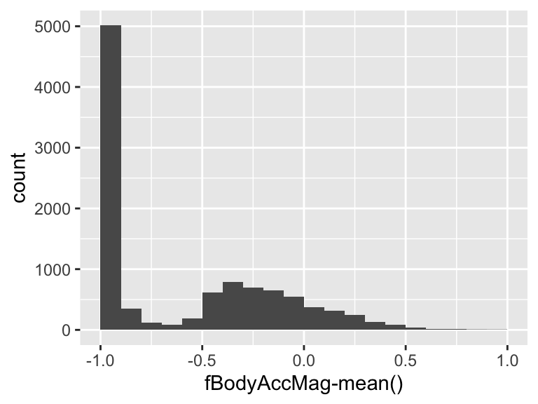

## fBodyAccMag-std()

| Feature | Result |
| --- | --- |
| Variable type | numeric |
| Number of missing obs. | 0 (0 %) |
| Number of unique values | 10298 |
| Median | -0.85 |
| 1st and 3rd quartiles | -0.98; -0.38 |
| Min. and max. | -1; 1 |

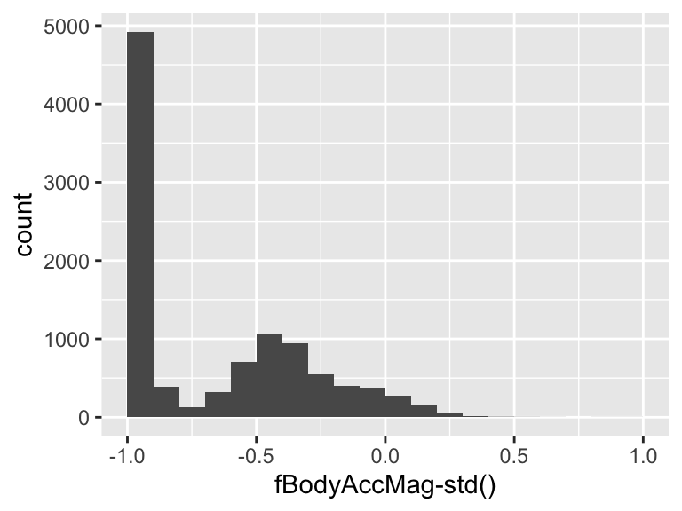

## fBodyAccMag-meanFreq()

| Feature | Result |
| --- | --- |
| Variable type | numeric |
| Number of missing obs. | 0 (0 %) |
| Number of unique values | 10299 |
| Median | 0.07 |
| 1st and 3rd quartiles | -0.1; 0.24 |
| Min. and max. | -1; 1 |

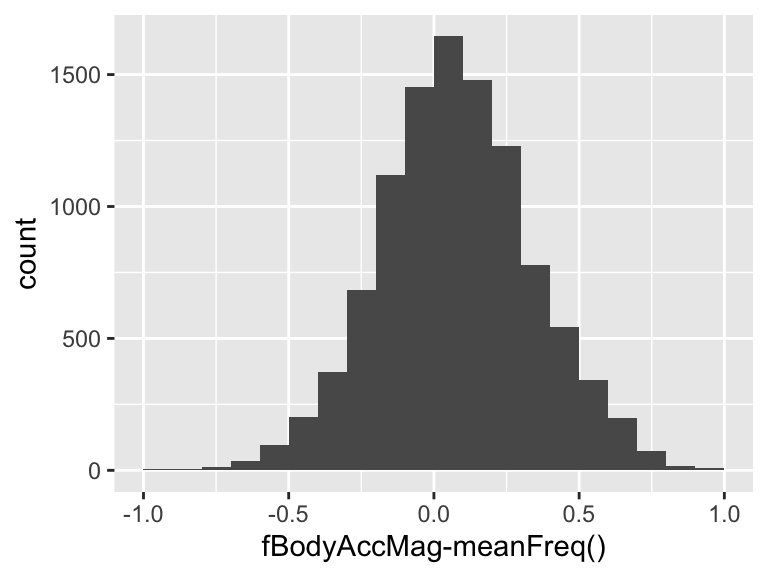

## fBodyBodyAccJerkMag-mean()

| Feature | Result |
| --- | --- |
| Variable type | numeric |
| Number of missing obs. | 0 (0 %) |
| Number of unique values | 10290 |
| Median | -0.93 |
| 1st and 3rd quartiles | -0.99; -0.26 |
| Min. and max. | -1; 1 |

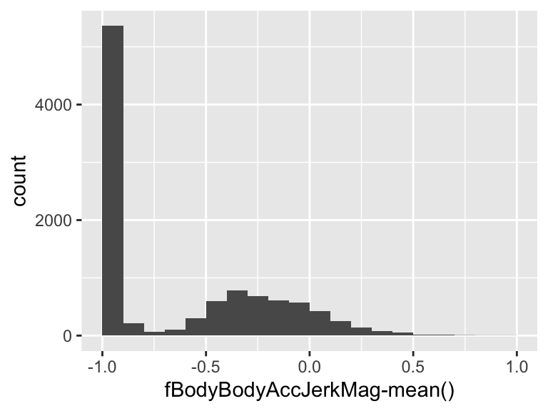

## fBodyBodyAccJerkMag-std()

| Feature | Result |
| --- | --- |
| Variable type | numeric |
| Number of missing obs. | 0 (0 %) |
| Number of unique values | 10296 |
| Median | -0.93 |
| 1st and 3rd quartiles | -0.99; -0.31 |
| Min. and max. | -1; 1 |

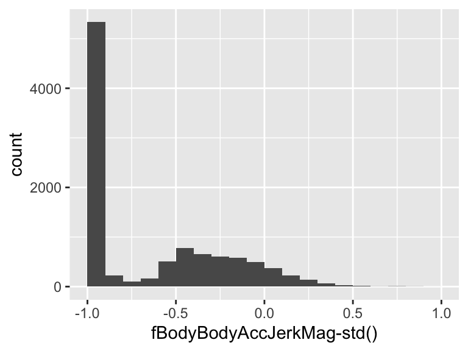

## fBodyBodyAccJerkMag-meanFreq()

| Feature | Result |
| --- | --- |
| Variable type | numeric |
| Number of missing obs. | 0 (0 %) |
| Number of unique values | 10299 |
| Median | 0.16 |
| 1st and 3rd quartiles | 0; 0.36 |
| Min. and max. | -1; 1 |

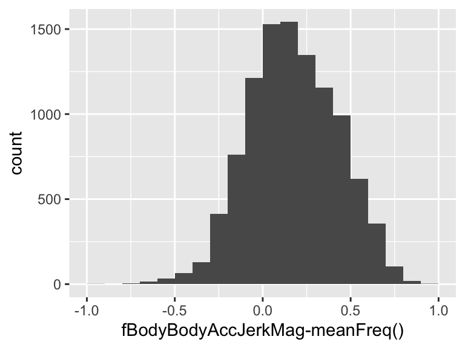

## fBodyBodyGyroMag-mean()

| Feature | Result |
| --- | --- |
| Variable type | numeric |
| Number of missing obs. | 0 (0 %) |
| Number of unique values | 10297 |
| Median | -0.88 |
| 1st and 3rd quartiles | -0.98; -0.45 |
| Min. and max. | -1; 1 |

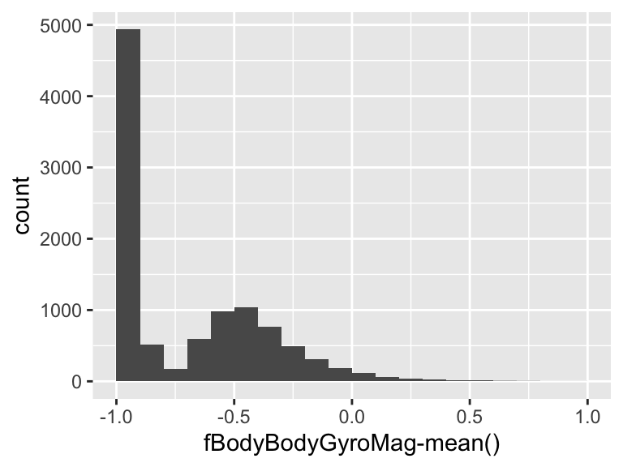

## fBodyBodyGyroMag-std()

| Feature | Result |
| --- | --- |
| Variable type | numeric |
| Number of missing obs. | 0 (0 %) |
| Number of unique values | 10296 |
| Median | -0.83 |
| 1st and 3rd quartiles | -0.98; -0.47 |
| Min. and max. | -1; 1 |

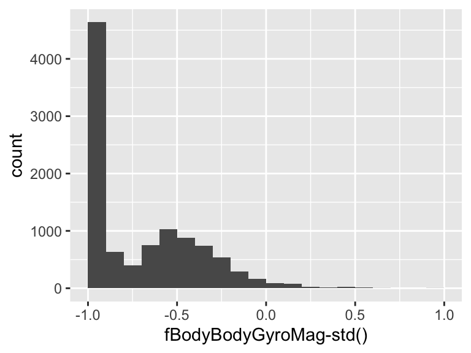

## fBodyBodyGyroMag-meanFreq()

| Feature | Result |
| --- | --- |
| Variable type | numeric |
| Number of missing obs. | 0 (0 %) |
| Number of unique values | 10299 |
| Median | -0.05 |
| 1st and 3rd quartiles | -0.23; 0.15 |
| Min. and max. | -1; 1 |

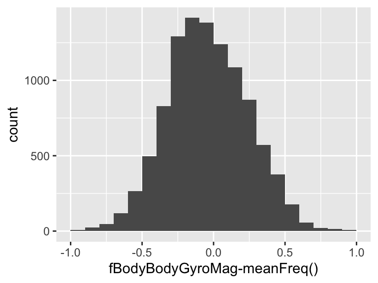

## fBodyBodyGyroJerkMag-mean()

| Feature | Result |
| --- | --- |
| Variable type | numeric |
| Number of missing obs. | 0 (0 %) |
| Number of unique values | 10293 |
| Median | -0.95 |
| 1st and 3rd quartiles | -0.99; -0.61 |
| Min. and max. | -1; 1 |

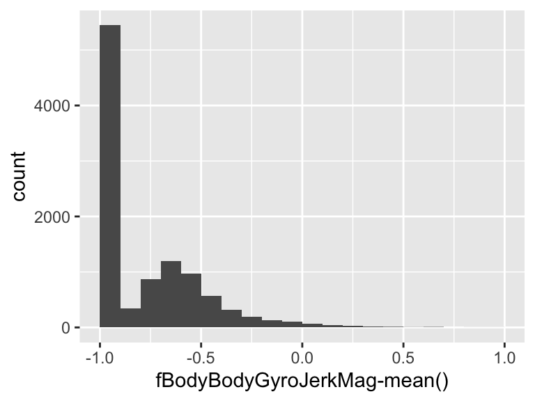

## fBodyBodyGyroJerkMag-std()

| Feature | Result |
| --- | --- |
| Variable type | numeric |
| Number of missing obs. | 0 (0 %) |
| Number of unique values | 10292 |
| Median | -0.94 |
| 1st and 3rd quartiles | -0.99; -0.64 |
| Min. and max. | -1; 1 |

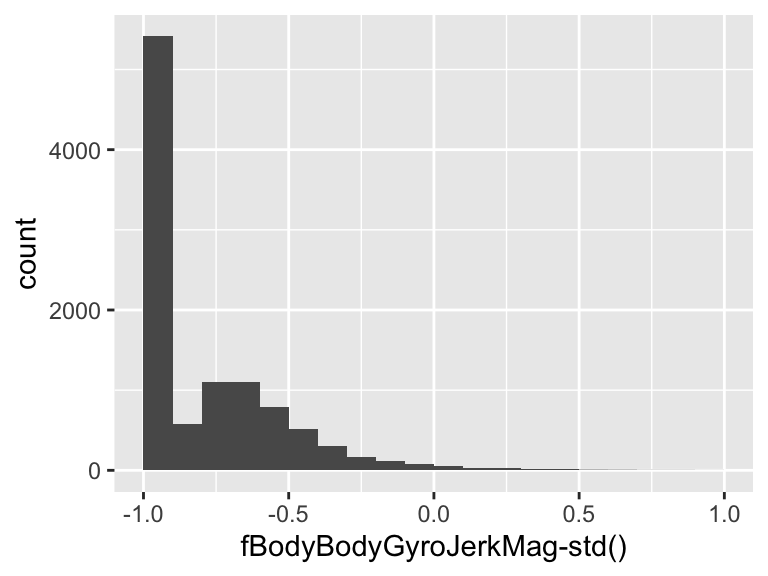

## fBodyBodyGyroJerkMag-meanFreq()

| Feature | Result |
| --- | --- |
| Variable type | numeric |
| Number of missing obs. | 0 (0 %) |
| Number of unique values | 10299 |
| Median | 0.14 |
| 1st and 3rd quartiles | -0.02; 0.29 |
| Min. and max. | -1; 1 |

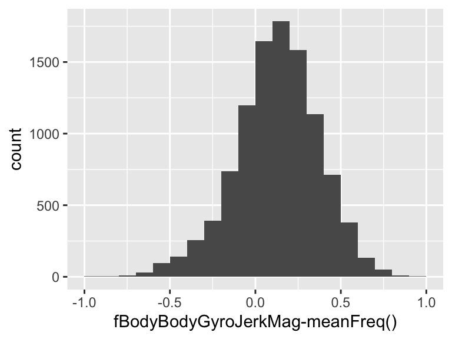

Report generation information:

- Created by: Gareth Coffey (username: `garethcoffey`).
- Report creation time: Sun Apr 26 2020 14:12:35
- Report was run from directory: `/Users/garethcoffey/Documents/RStudio/Getting and Cleaning Data/Week 4/CleaningData-Week4-Assignment`
- dataMaid v1.4.0 [Pkg: 2019-12-10 from CRAN (R 3.6.0)]
- R version 3.6.3 (2020-02-29).
- Platform: x86_64-apple-darwin15.6.0 (64-bit)(macOS Catalina 10.15.4).
- Function call: `dataMaid::makeDataReport(data = combined, mode = c("summarize", "visualize", "check"), smartNum = FALSE, file = "codebook_combined.Rmd", checks = list(character = "showAllFactorLevels", factor = "showAllFactorLevels", labelled = "showAllFactorLevels", haven_labelled = "showAllFactorLevels", numeric = NULL, integer = NULL, logical = NULL, Date = NULL), listChecks = FALSE, maxProbVals = Inf, codebook = TRUE, reportTitle = "Codebook for combined")`